# User Guide

hemi luan

2025-11-04

## Introduction

Liquid chromatography - mass spectrometry (LC-MS) based non-targeted metabolomics and chemical exposomics can qualitatively and quantitatively measure known and unknown chemical molecules in the internal and external environments of life. These chemical molecules are typically represented as features. Although features may represent all detected chemical molecules, most features are often unidentified in high-resolution mass spectrometry. Understanding this issue is crucial for the annotation and interpretation of metabolomics and chemical exposomics data, as well as for the future development of this field. To overcome this challenge, the software **CPVA 2.0** was developed, empowering users to create interactive displays to support data exploration. These displays are easy to share and are not dependent on specific operating systems. CPVA 2.0 allows users to interactively optimize feature extraction parameters and evaluate the peak morphology confidence . It also enables users to assess the quality of each feature by starting from the raw mass spectrometry data, performing feature extraction, feature annotation and chromatographic peak evaluation.

**Main modules**: Tune, Features and SmartChrom

## Module 1: Tune

### Loading and Visualizing LC-MS Data

#### Loading Data Files

1. Click the Select LC-MS data files button to open a file browser dialog.
2. Select one or more mzML or mzXML files containing MS1-level spectra for processing.
3. Upon selection, the files will be loaded and displayed in the file list panel.

#### Data Visualization

1. Select any loaded file from the list to visualize its key chromatograms and spectra.
2. The interface will display:

```
 Total Ion Chromatogram (TIC): The summed intensity of all ions detected at each retention time.

 Base Peak Chromatogram (BPC): The intensity of the most abundant ion at each retention time.

 MS1 Spectra Browser: Interactive display of mass spectra for individual scans.
```

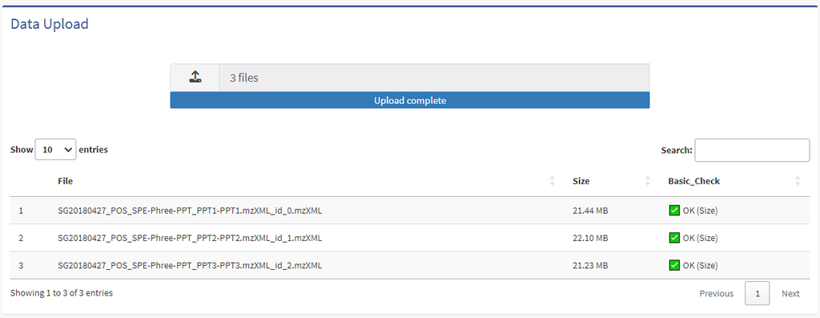

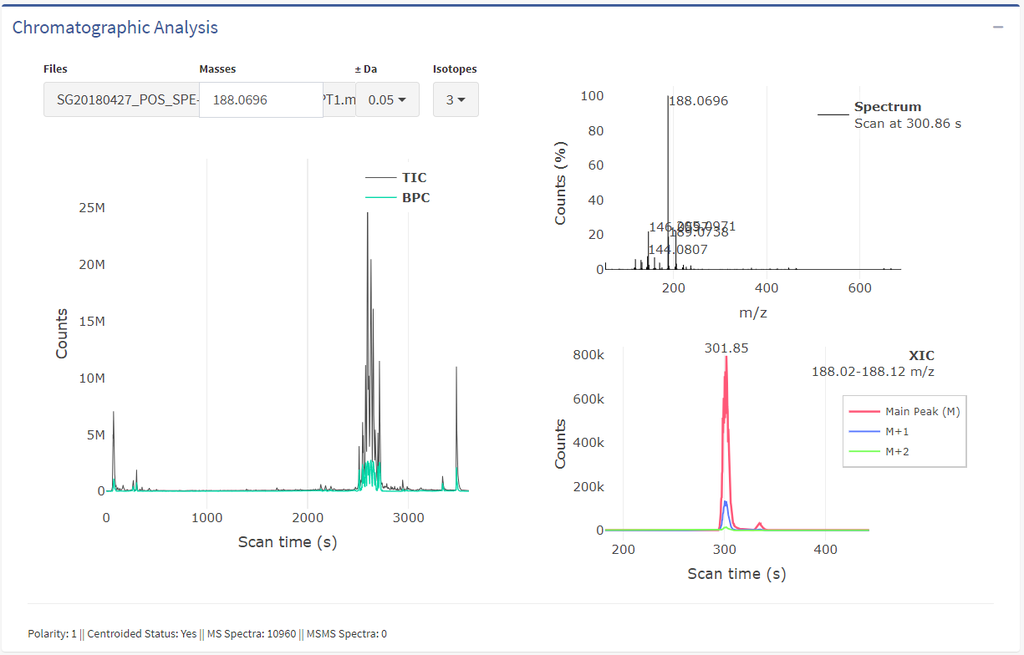

### Optimizing Peak Detection Parameters

#### Running Initial Peak Detection

1. Adjust the peak picking parameters in the left panel according to your analytical system and requirements.
2. Click the Submit button to execute the XCMS-based peak detection algorithm with the specified parameters.
3. The results, including extracted features and processing summaries, will appear in the Feature View tab.
4. Click Save to export the current parameter set for future use or reproducibility.

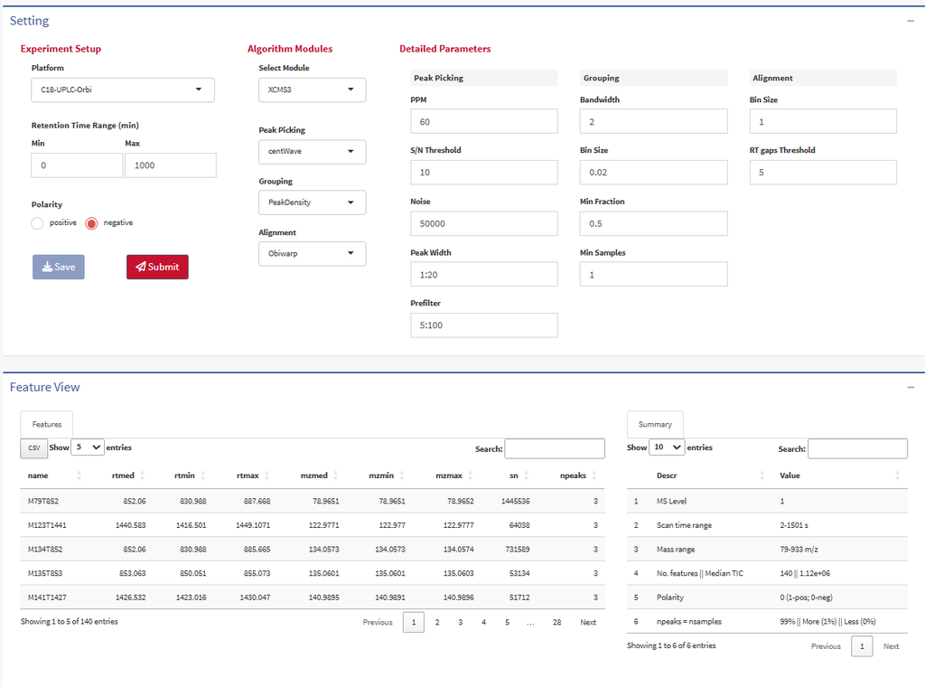

#### Visualizing Mass Traces and Chromatograms

1. To refine m/z tolerance and bandwidth parameters, specify a target m/z and retention time range.
2. Click Submit to generate visualizations that aid in parameter optimization:

```
Mass Traces Plot: Shows extracted ion chromatograms for the specified m/z window, helping assess m/z alignment.

Feature Chromatograms: Displays individual peak shapes for quality assessment.

Peak Density Plot: Visualizes peak distribution across the retention time axis, informing bandwidth selection.
```

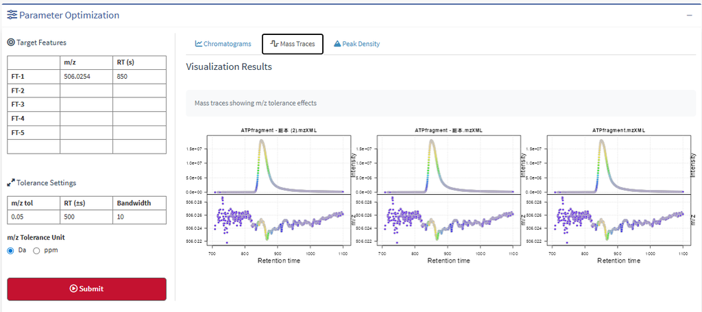

The mass traces plot

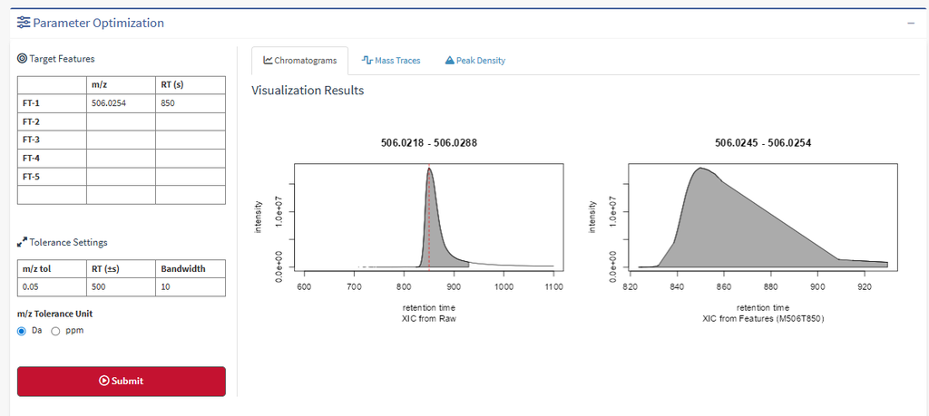

The feature chromatograms

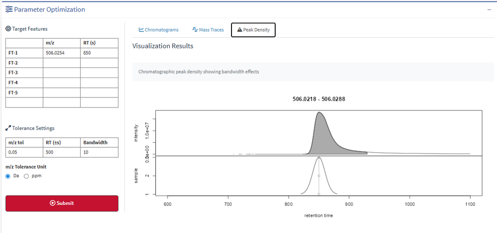

The peak density

### Parameter Reference

#### Peak Detection (centWave Algorithm)

This algorithm is optimized for high-resolution LC-MS data. Key parameters include:

```
ppm: Maximum tolerated m/z deviation, expressed in parts per million (ppm). Defines the width of the m/z window for chromatographic peak detection.

peakwidth: Expected chromatographic peak width range (minimum, maximum) in seconds. Should be estimated from representative chromatograms.

snthresh: Signal-to-noise ratio threshold. Peaks with lower signal-to-noise ratios are filtered out.

prefilter: Criteria for retaining mass traces during Region of Interest (ROI) detection. Requires at least k data points with intensity ≥ I.

noise: Absolute intensity threshold. Data points below this value are excluded from initial processing steps.

mzdiff: Minimum m/z difference required to distinguish co-eluting peaks. Can be set to negative values to allow peak overlap.
```

#### Peak Grouping (Peak Density Algorithm)

Parameters controlling the alignment of peaks across samples:

```
bw (bandwidth): Smoothing parameter for the retention time density estimation. Larger values group more widely spaced peaks.

minFrac: Minimum fraction of samples (within any experimental group) where a peak must be detected for it to be retained as a feature.

minsamp: Minimum absolute number of samples (within any group) where a peak must be detected.

binSize: Size (in m/z units) of the bins used for grouping peaks across samples during the alignment step.
```

## Module 2: Features

### Data Import and Processing Setup

#### Loading Data for Feature Extraction

1. Click Select MS data files to import mzML/mzXML files for comprehensive feature analysis.
2. For studies with targeted compounds or regions of interest, use the Hybrid peak extraction option by specifying:

```
Precursor m/z value(s)

Retention time window (in seconds)
```

#### Processing Data-Dependent Acquisition (DDA) Data

1. For experiments acquired in DDA mode, select the DDA processing option.
2. CPVA will correlate MS1 features with their corresponding MS/MS spectra.
3. Features are annotated regarding in-source fragmentation:

```
L1 Annotation: Fragment ion is present in the associated MS/MS spectrum and shows high correlation with the precursor.

L2 Annotation: Fragment ion is present in the MS/MS spectrum.
```

### Configuring Processing Parameters

1. Click the Parameters button to load a previously saved parameter file (e.g., from the Tune module).
2. For large datasets, enable Parallel processing to distribute computational load across multiple CPU cores and reduce processing time.
3. Click Start analysis to initiate the comprehensive feature extraction workflow.

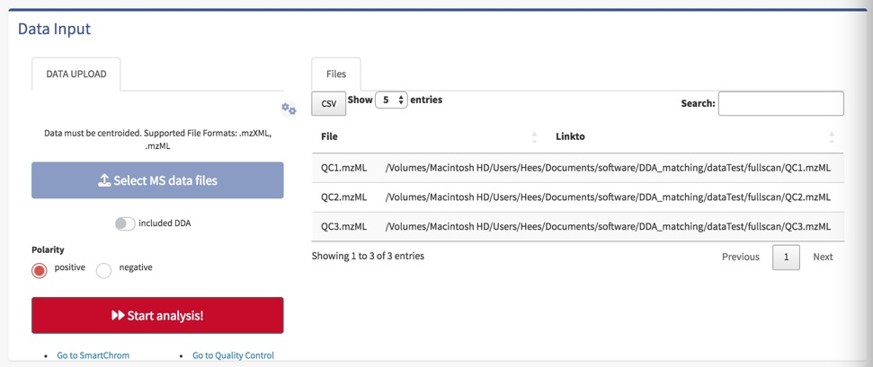

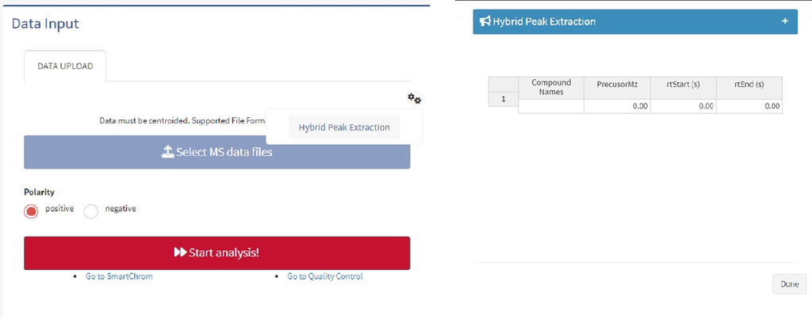

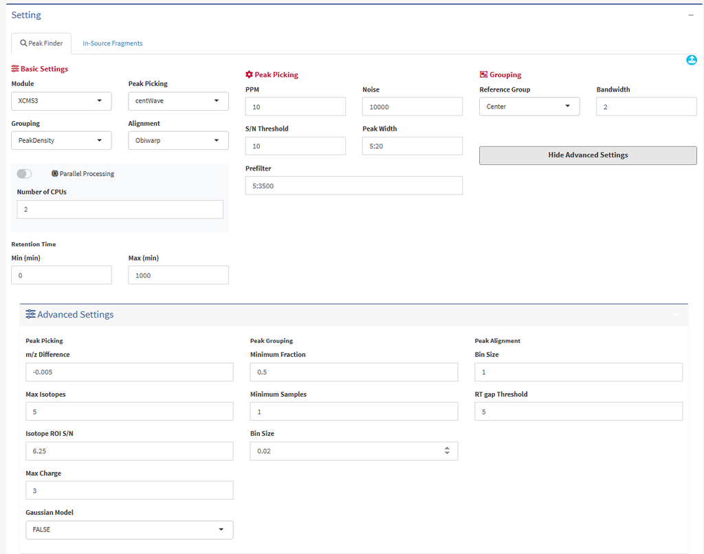

### Feature Extraction and Review

#### Reviewing Processing Results

1. After analysis completion, the interface presents multiple tabs for result exploration:

```
Feature Table: A comprehensive list of all detected features with annotations.

Visualizations: Multiple plots for quality assessment.
```

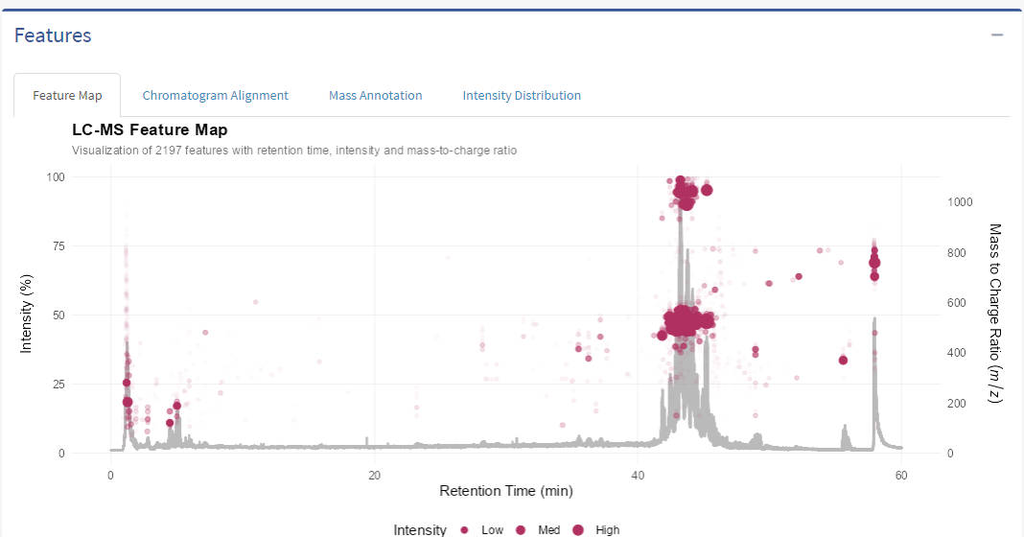

Global overview of chromatographic peaks

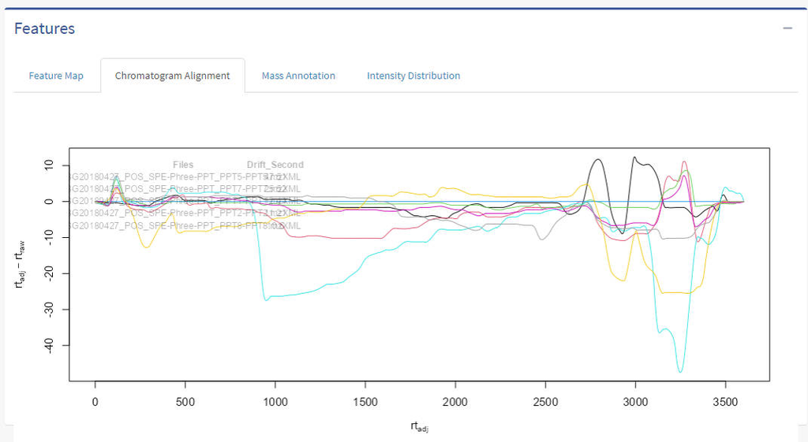

The difference between the adjusted and raw retention times

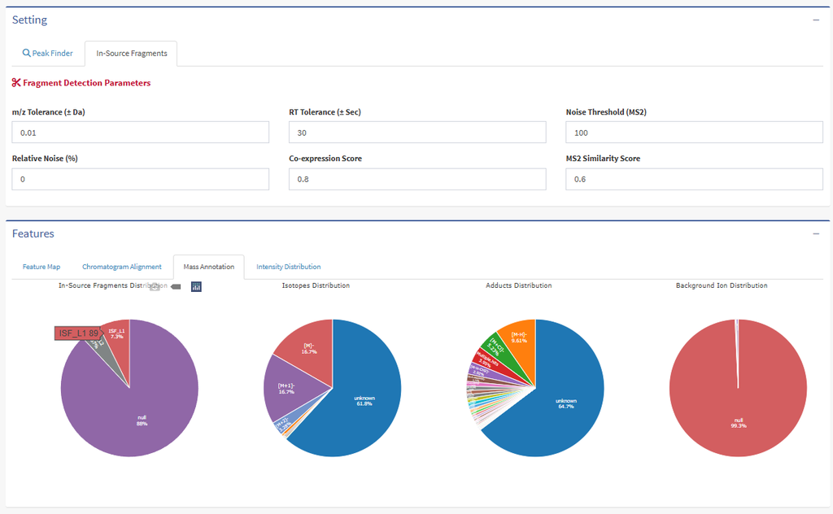

Annotation of ISF, adducts, isotopes and background contaminants

#### Understanding Feature Annotations

The feature table provides comprehensive information for each detected analyte:

```
name: Feature name

rtmed: Median retention time.

mzmed: Median mz value.

fragCount: Number of fragment ions in MS2 spectrum.

ISFrag: Ion-source fragments. L1 represents the fragment exists in the MS/MS spectrum and has high correlation, L2 represents the fragment exists in the MS/MS spectrum.

isotopes:  The isotope peaks are denoted as [M + 1], [M + 2], … ions. [M + 1] is the first isotopic peak for the monoisotopic peak [M].

adduct: Adducts are generally observed in ESI-MS data. The protonated molecular ion ([M+H]+) is accompanied by kinds of adduct formation, such as [M + Na]+, [M + K]+, [M + NH4]+, etc.

backgroundIon: Background ions are frequently observed in MS background. Common MS background ions including 782 species were collected as in-house backgroundIon database.

chromatogram: The represented chromatogram for each feature will be shown with Sparkline (the Chromatogram spark or DDA should be selected).
```

#### Managing the Feature Table

1. Edit feature names or notes directly in the table.
2. Click Save to commit all changes to the project file.

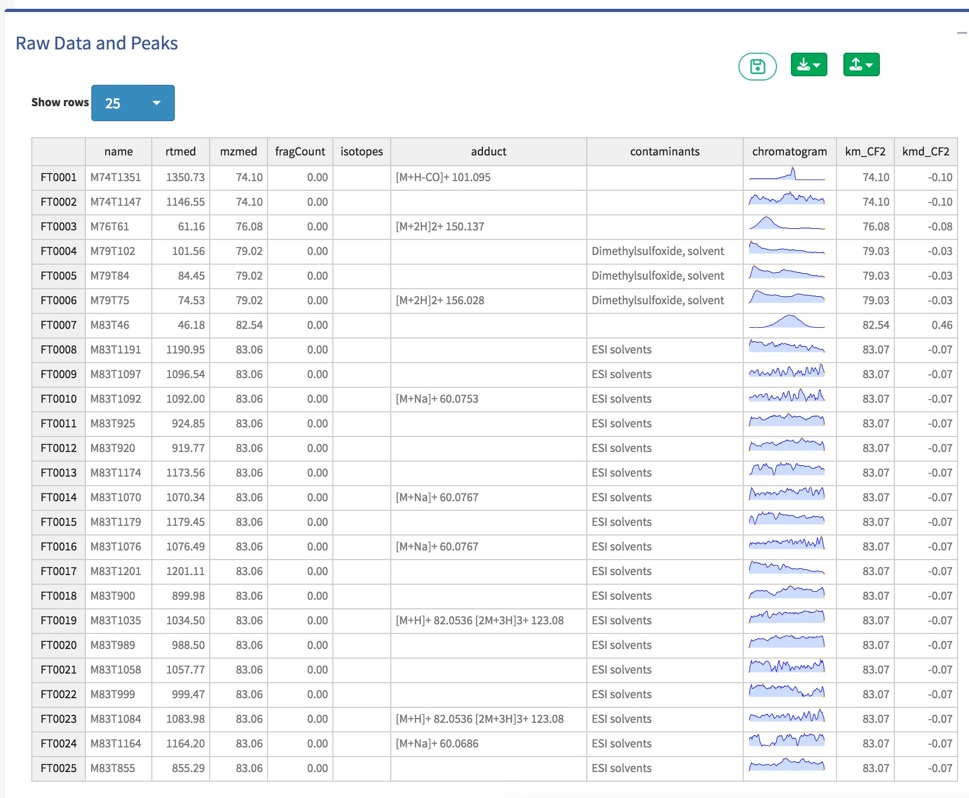

### Data Export and Project Management

#### Exporting Results

1. Click Download to export:

```
Complete feature table (CSV format)

Annotated MS/MS spectra (if available)
```

#### Saving and Loading Projects (offline version)

1. CPVA automatically creates a .cpva project file containing all processed data and annotations.
2. Click Upload to resume work on a previously saved project.
3. Project files maintain complete processing history and user annotations.

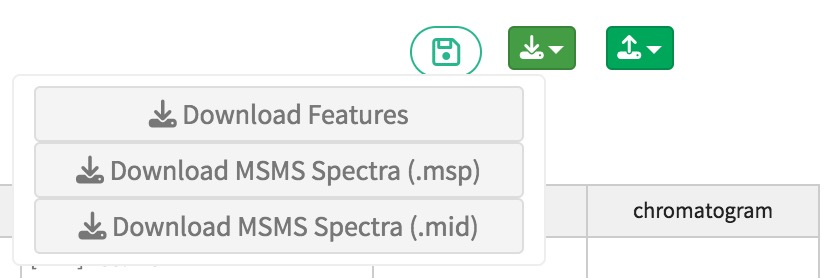

## Module 3: SmartChrom

### Assessing Chromatographic Quality

SmartChrom provides automated assessment of chromatographic peak quality using multiple orthogonal metrics. The module assigns quality scores and visual indicators:

```
Blue Indicators: High-confidence peaks with optimal chromatographic properties.

Red Indicators: Low-confidence peaks requiring further inspection or potential exclusion.
```

### Chromatographic Quality Metrics

SmartChrom evaluates peaks using seven complementary metrics:

```
FWHM2Base Ratio: Ratio of Full Width at Half Maximum (FWHM) to the total peak width at baseline. Lower ratios indicate tailing or fronting peaks.

Gaussian Similarity: Dot product between the normalized peak and an ideal Gaussian fit. Measures peak symmetry.

ZigZag Index: Quantifies high-frequency noise along the peak apex, normalized by boundary intensities.

Sharpness: Sum of intensity differences between adjacent points, normalized by peak boundary intensity. Higher values indicate steeper peak flanks.

Triangular Peak Area Similarity Ratio (TPASR): Ratio of the integrated peak area to the area of a triangle formed by the peak apex and boundaries.

Beta Correlation (Beta_cor): Pearson correlation between the raw peak and a fitted beta distribution.

Beta Signal-to-Noise (Beta_snr): Signal-to-noise ratio derived from the residuals of the beta distribution fit.
```

### Applying Quality Filters

1. Review the quality scores assigned to each feature.

2.Use the interactive plots to identify features with poor chromatographic characteristics.

3. Filter features based on quality thresholds for downstream statistical analysis.
4. Click Save to export the quality-annotated feature table.

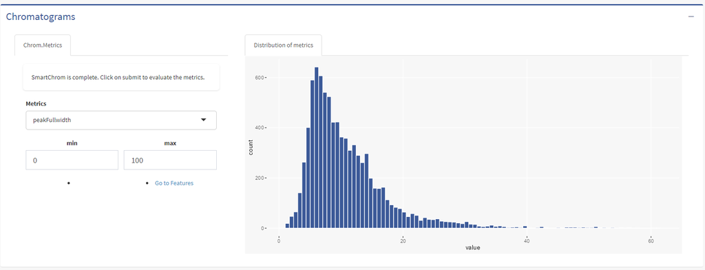

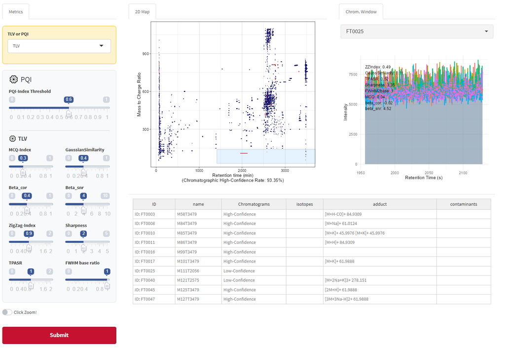